# WP1: Simple View - Latent Profile Analysis

12/08/2021

This script is used for running the latent profile models. This script (rather than the factor mixture model alternative WP1_SimpView_FMM.Rmd) was selected on the basis of the CFA results, which found that the two-factor structure was not a good fit. This analysis is conducted using the “exploratory” or “calibration” half of the dataset (subsample A).

The pre-registration for this analysis can be found [here](https://osf.io/4zahf). Note one key deviation from this plan from the outset of this script is that the word and nonword reading measures were combined into a single item accuracy score. This decision was made after encountering errors with the initial latent profile models: the word reading measure could not be modelled continuously given its discrete nature and high negative skew. Combining the word and nonword reading measures into a single composite score in the present analyses enabled more robust models across different k-class solutions for comparison.

# Set-up

## Libraries

*Package versions were up-to-date as of 12/08/2021. Version information can be found at the end of the output file.*

*Models were run using Mplus Version 8.5.*

```r
# Specify packages
pkgs <- c("tidyverse", "MplusAutomation", "texreg", "DiagrammeR", "kableExtra", "ggalluvial", "scales", "rlist", "here")

# Load all packages
invisible(lapply(pkgs, library, character.only = TRUE))
```

## Directories

```r
# Create subdirectories for storing mplus scripts, data files, and output, if do not already exist
if(dir.exists("./mplus_models/")==FALSE){dir.create("./mplus_models/")}
if(dir.exists("./mplus_models/simpview/")==FALSE){dir.create("./mplus_models/simpview/")}
if(dir.exists("./mplus_models/simpview/lpa_comp")==FALSE){dir.create("./mplus_models/simpview/lpa_comp")}
if(dir.exists("../output/")==FALSE){dir.create("../output/")}
if(dir.exists("../output/figures")==FALSE){dir.create("../output/figures")}
if(dir.exists("../output/tables")==FALSE){dir.create("../output/tables")}
```

## Functions

Functions for processing the output are stored in a separate script.

```r
source("WP1_OutputFunctions.R")
```

## Data

This analysis is developed on half of the dataset, for subsequent cross-validation with the remaining half (WP1_SimpView_CrossValidation.Rmd).

```r
sv_data <- read.csv("../data/processed/WP1_data_subA.csv")  %>%       # ALSPAC data

  # Select and format relevant variables
  select(yp_id, cidB3153, age_m_f8, age_m_f9,
                nara_acc_raw_f9, read_word_raw_f9, read_nonw_raw_f9,  # reading accuracy variables
                nara_comp_raw_f9, wold_comp_raw_f8) %>%               # comprehension variables
  mutate(combAcc = read_word_raw_f9 + read_nonw_raw_f9) %>%           # create combined item accuracy score
  select(-read_word_raw_f9, -read_nonw_raw_f9) %>%                    # remove other measures

  # Rename for Mplus character limit
  rename(naraComp = nara_comp_raw_f9,
         naraAcc = nara_acc_raw_f9,
         woldComp = wold_comp_raw_f8,
         f8age = age_m_f8,
         f9age = age_m_f9) %>%

  # Change ID to a factor
  mutate(yp_id = as.factor(yp_id))
```

# Class enumeration

**Aim: to fit models of different n classes, at range of different model specifications.**

Indicator variances can always differ from each other within a class, but different model specifications vary in whether they are separately estimated between classes. Labels for different specifications taken from Pastor (2007) and Masyn (2013).

## Base model

### Set-up

*Note: Models were edited to increase starts if best log-likelihood value not replicated. Initial plan to increase to 2000 200 (Lubke & Luningham, 2017), but increased further where necessary (code in raw script).*

Create base model with basic set-up, including age covariates. Specify other model elements for use in different models.

```r
# Create base model
m_lpa_base <- mplusObject(
  TITLE = "Latent Profile Analysis;",
  ANALYSIS = "estimator = mlr; type = mixture; starts = 500 50;
              processors = 4(STARTS);",
  VARIABLE = "idvariable = cidB3153; classes = c(1);",
  MODEL = "%OVERALL%
           f8age; f9age;
           combAcc naraAcc naraComp on f9age;
           woldcomp on f8age;",
  OUTPUT = "TECH1 TECH8;",
  PLOT = "TYPE = PLOT3;",
  usevariables = colnames(sv_data[,!names(sv_data) %in% c("yp_id")]),
  rdata = sv_data)

# Specify all variances
lpa_vars <- "naraComp; naraAcc; combAcc; woldComp;"

# Specify all covariances
lpa_covars <- "
  naraComp with naraAcc;
  naraComp with combAcc;
  naraComp with woldComp;
  naraAcc with combAcc;
  naraAcc with woldComp;
  combAcc with woldComp;  "

# Specify no covariances
no_covars <- "
  naraComp with naraAcc@0;
  naraComp with combAcc@0;
  naraComp with woldComp@0;
  naraAcc with combAcc@0;
  naraAcc with woldComp@0;
  combAcc with woldComp@0;  "
```

### Benchmark

Follow class-enumeration process set out by Masyn (2013). Use a one-class LPA (incorporating sample means and covariances) as an absolute fit benchmark.

```r
# Specify benchmark model
m_lpa_benchmark <- update(m_lpa_base,
     TITLE = ~ "LPA Benchmark",
     VARIABLE = ~ "idvariable = cidB3153; classes = c(1);",
     MODEL = as.formula(sprintf("~ . + '%%OVERALL%% \n %s \n %s'", lpa_vars, lpa_covars)))

# Run benchmark model
# mplusModeler(m_lpa_benchmark, "./mplus_models/simpview/lpa_comp/sv_lpa_mbench.dat", run = TRUE)

# Extract parameters for the benchmark model
lpa_benchmark <- readModels(target = "./mplus_models/simpview/lpa_comp", filefilter = "mbench") %>%
  mixtureSummaryTable(keepCols = c("Parameters", "Observations", "LL", "BIC")) %>%
  mutate(CAIC = -2*LL + Parameters*(log(Observations) + 1),
         AWE = -2*LL + Parameters*(log(Observations) + 1.5)) %>%
  select(LL, BIC, CAIC, AWE) %>%
  pivot_longer(LL:AWE, names_to = "statistic", values_to = "benchmark") %>%
  mutate(statistic_relevel = factor(statistic, levels = c("LL", "BIC", "CAIC", "AWE")))
```

## Model A: Class-invariant, diagonal

**Indicator variances differ from each other within a class, but are constrained to be equal across classes.** **No covariances are estimated.**

### Specification

**Steps 1-3)** Fit series of increasing *k*-class models.

*Note: Started by fitting up to 6-class models, but increased the number of classes after adjusted LRTs and Bayes Factors implied there might be continued improvements in model fit for some specifications. To be thorough, we ran preliminary models up to 10-classes (the maximum specified in our pre-registration). However, 9- and 10-class models were not generally good fits across model types (and often did not converge on a single solution), and are not presented in the manuscript.*

```r
# Fit initial models
m_lpa_a <- lapply(1:10, function(k) {
   body <- update(m_lpa_base,
     TITLE = as.formula(sprintf("~ 'LPA Model A: %d classes;'", k)),
     VARIABLE = as.formula(sprintf("~ 'idvariable = cidb3153; classes = c(%d);'", k)),
     MODEL = as.formula(sprintf("~ . + '%s %s'", lpa_vars, no_covars)))

   mplusModeler(body, sprintf("mplus_models/simpview/lpa_comp/sv_lpa_a_%dclass.dat", k), run = FALSE)
 })
```

Use optseed to re-compute adjusted LRT tests (Lo-Mendell-Rubin; Vuong-Lo-Mendell-Rubin). This was added after initial fitting to check that the k-1 model used in the LRT tests had the same loglikelihood as the model fitted above, and can permit re-running of the test with increased k-1starts if the k-1 model does not have the same loglikelihood as the model fitted above ([Asparouhov & Muthen, 2012](https://www.statmodel.com/examples/webnotes/webnote14.pdf)).

```r
# Read in output
lpa_a_out <- readModels(target = "./mplus_models/simpview/lpa_comp", filefilter = "sv_lpa_a_([1-9])")

# Check LMR tests
lpa_a_lmr <- recomp_LMR(orig_mods = m_lpa_a,
                        orig_output = lpa_a_out,
                        mods = c(1:length(lpa_a_out)),
                        #mods = c(9, 10),        # used to specify individual models for re-rerunning
                        #kstarts = "6000 1500",  # used for re-running if necessary
                        filepath = "mplus_models/simpview/lpa_comp",
                        rerun = FALSE
                        )

# Check whether any warnings remain
lpa_enum_table(lpa_a_lmr, LMR_warn = TRUE) %>%
  select(Specification, Classes, LMR_check) %>%
  filter(!is.na(LMR_check))
```

```
##               Specification Classes  LMR_check
## 1   LPA Model A: 2 classes;       2
## 2   LPA Model A: 3 classes;       3
## 3   LPA Model A: 4 classes;       4
## 4   LPA Model A: 5 classes;       5
## 5   LPA Model A: 6 classes;       6
## 6   LPA Model A: 7 classes;       7
## 7   LPA Model A: 8 classes;       8
## 8   LPA Model A: 9 classes;       9 Re-run LMR
## 9  LPA Model A: 10 classes;      10 Re-run LMR
```

Note that the LMR tests for 9- and 10-class models do not reach the same solutions for the k-1 model as the initial model fitted (tried up to 6000 1500 starts). However, as indicated by the fit indices below, these higher class models are unlikely to be useful.

### Indices

**Steps 4-5)** Extract fit indices, and use to select smaller subset of candidate models.

```r
# Read in output
lpa_a_lmr <- readModels(target = "./mplus_models/simpview/lpa_comp", filefilter = "(lpa_a_lmr_)([1-9])")

# Print table
lpa_a_summary <- lpa_enum_table(output = lpa_a_lmr)
lpa_a_summary[c(9, 10), c(8, 9)] <- NA  # Remove values from non-trusted k-1 comparisons
lpa_a_summary %>% kable("pipe")
```

| Specification | Classes | LL | Parameters | BIC | CAIC | AWE | VLMR_p | LMR_p | BF | cmP_k |
| --- | --- | --- | --- | --- | --- | --- | --- | --- | --- | --- |
| LPA Model A: 1 classes; | 1 | -60382.88 | 17 | 120904.1 | 120921.1 | 120929.6 | NA | NA | NA | 0 |
| LPA Model A: 2 classes; | 2 | -57767.55 | 24 | 115730.4 | 115754.4 | 115766.4 | <0.01 | <0.01 | >100 | 0 |
| LPA Model A: 3 classes; | 3 | -56707.57 | 31 | 113667.4 | 113698.4 | 113713.9 | <0.01 | <0.01 | >100 | 0 |
| LPA Model A: 4 classes; | 4 | -56171.22 | 38 | 112651.7 | 112689.7 | 112708.7 | <0.01 | <0.01 | >100 | 0 |
| LPA Model A: 5 classes; | 5 | -55766.09 | 45 | 111898.4 | 111943.4 | 111965.9 | <0.01 | <0.01 | >100 | 0 |
| LPA Model A: 6 classes; | 6 | -55493.25 | 52 | 111409.7 | 111461.7 | 111487.7 | 0.19 | 0.19 | >100 | 0 |
| LPA Model A: 7 classes; | 7 | -55281.56 | 59 | 111043.3 | 111102.3 | 111131.8 | 0.41 | 0.42 | >100 | 0 |
| LPA Model A: 8 classes; | 8 | -55099.07 | 66 | 110735.3 | 110801.3 | 110834.3 | 0.19 | 0.20 | >100 | 0 |
| LPA Model A: 9 classes; | 9 | -54994.89 | 73 | 110583.9 | 110656.9 | 110693.4 | NA | NA | >100 | 0 |
| LPA Model A: 10 classes; | 10 | -54905.94 | 80 | 110462.9 | 110542.9 | 110582.9 | NA | NA | >100 | 1 |

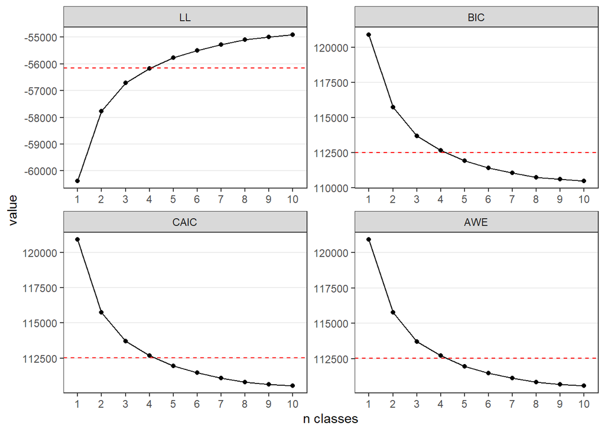

```r
# Elbow plots for information criteria
lpa_enum_elbow(lpa_a_summary, benchmark_stats = lpa_benchmark)
```

Best model for:

**a) Absolute fit** (fewest classes with better LL than benchmark)**:** *5-class*  
**b) Information heuristics** (diminishing gains from elbow plots)**:** *3-class*  
**c) Adjusted LRTs** (fewest classes not sig improved by additional classes)**:** *5-class*  
**d) Approximate BF** (fewest classes with moderate-strong evidence compared to previous model): *10-class/NA*  
**e) Approximate correct model probability:** *10-class*

### Inspection

**Step 6)** View classification diagnostics for candidate models. Can also inspect how the classes correspond across models.

```r
# Extract participant level data
lpa_a_rerun <- mm_extract_data(orig_mods = m_lpa_a, orig_output = lpa_a_out,
                               candidate_mods = c(5:6),
                               filepath = "mplus_models/simpview/lpa_comp",
                               rerun = FALSE, optseed = TRUE,
                               one_fit = TRUE)

# Print table, and append bLRT values to main output
lpa_a_summary <- add_bLRT(lpa_a_rerun, lpa_a_summary)
lpa_a_summary %>% kable("pipe")
```

| Specification | Classes | Parameters | LL | BIC | CAIC | AWE | VLMR_p | LMR_p | bLRT_p | BF | cmP_k |
| --- | --- | --- | --- | --- | --- | --- | --- | --- | --- | --- | --- |
| LPA Model A: 1 classes; | 1 | 17 | -60382.88 | 120904.1 | 120921.1 | 120929.6 | NA | NA | NA | NA | 0 |
| LPA Model A: 2 classes; | 2 | 24 | -57767.55 | 115730.4 | 115754.4 | 115766.4 | <0.01 | <0.01 | NA | >100 | 0 |
| LPA Model A: 3 classes; | 3 | 31 | -56707.57 | 113667.4 | 113698.4 | 113713.9 | <0.01 | <0.01 | NA | >100 | 0 |
| LPA Model A: 4 classes; | 4 | 38 | -56171.22 | 112651.7 | 112689.7 | 112708.7 | <0.01 | <0.01 | NA | >100 | 0 |
| LPA Model A: 5 classes; | 5 | 45 | -55766.09 | 111898.4 | 111943.4 | 111965.9 | <0.01 | <0.01 | <0.01 | >100 | 0 |
| LPA Model A: 6 classes; | 6 | 52 | -55493.25 | 111409.7 | 111461.7 | 111487.7 | 0.19 | 0.19 | <0.01 | >100 | 0 |
| LPA Model A: 7 classes; | 7 | 59 | -55281.56 | 111043.3 | 111102.3 | 111131.8 | 0.41 | 0.42 | NA | >100 | 0 |
| LPA Model A: 8 classes; | 8 | 66 | -55099.07 | 110735.3 | 110801.3 | 110834.3 | 0.19 | 0.20 | NA | >100 | 0 |
| LPA Model A: 9 classes; | 9 | 73 | -54994.89 | 110583.9 | 110656.9 | 110693.4 | NA | NA | NA | >100 | 0 |
| LPA Model A: 10 classes; | 10 | 80 | -54905.94 | 110462.9 | 110542.9 | 110582.9 | NA | NA | NA | >100 | 1 |

```r
# Compute classification diagnostics
class_diag(lpa_a_rerun)
```

```
## [1] "CLASSIFICATION DIAGNOSTICS FOR  LPA MODEL A: 5 CLASSES;"
## [1] "Entropy: 0.858"
##
## [1] "Average posterior class probability:"
##     1     2     3     4     5
## 0.913 0.834 0.910 0.941 0.865
##
## [1] "Odds of correct classification ratio:"
##   1   2   3   4   5
## 157 115  41  25  14
## [1] "Good class separation and assignment accuracy (Nagin, 2005)"
##
## [1] "Model estimated proportion for each class:"
## [1] 0.06251 0.04188 0.19953 0.38687 0.30921
##
## [1] "Proportion modally assigned to each class:"
## [1] 0.06018 0.03827 0.20216 0.39147 0.30792
##
## [1] "--------------------------------------------"
##
## [1] "CLASSIFICATION DIAGNOSTICS FOR  LPA MODEL A: 6 CLASSES;"
## [1] "Entropy: 0.866"
##
## [1] "Average posterior class probability:"
##     1     2     3     4     5     6
## 0.905 0.866 0.937 0.900 0.809 0.833
##
## [1] "Odds of correct classification ratio:"
##   1   2   3   4   5   6
##  39  15  24 156 219 111
## [1] "Good class separation and assignment accuracy (Nagin, 2005)"
##
## [1] "Model estimated proportion for each class:"
## [1] 0.19717 0.30757 0.37888 0.05442 0.01901 0.04294
##
## [1] "Proportion modally assigned to each class:"
## [1] 0.20012 0.30821 0.38212 0.05229 0.01811 0.03915
##
## [1] "--------------------------------------------"
```

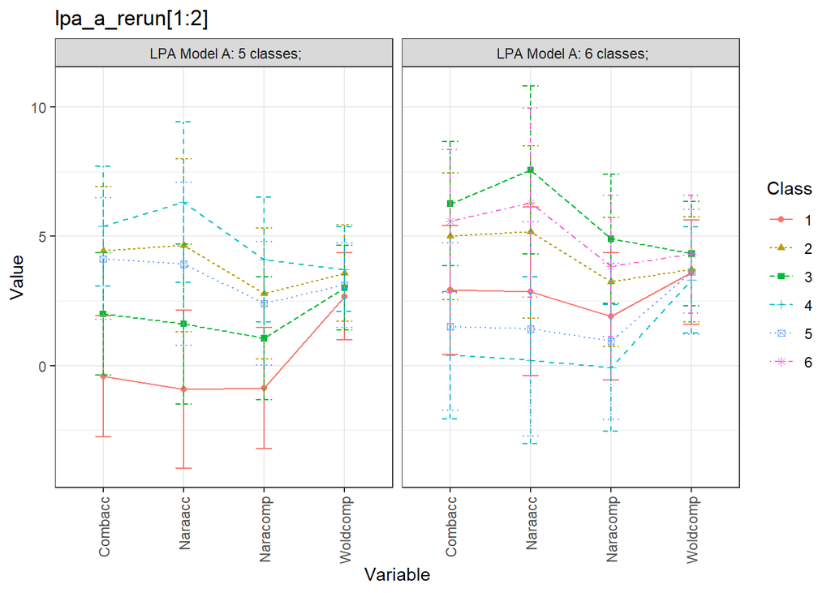

```r
# Plot class means
plotMixtures_simpView(lpa_a_rerun[1:2])
```

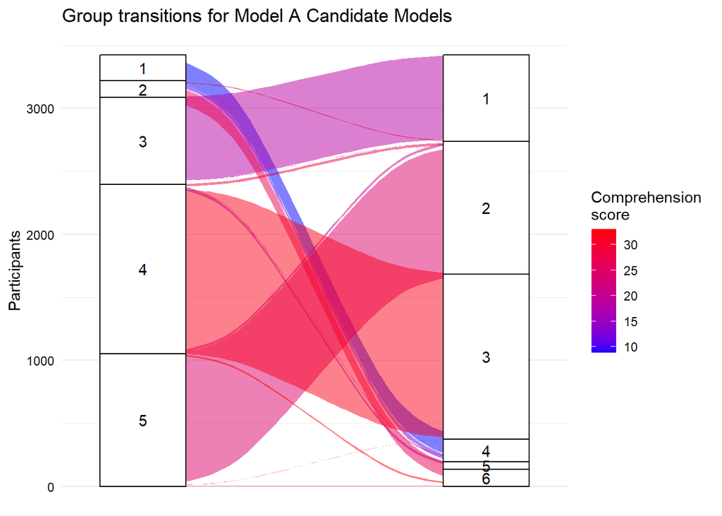

```r
# Inspect transitions
extract_classes(lpa_a_rerun[1:2], type = "lpa")
```

**Comments:**

- **Classification diagnostics:** *Average posterior class probability good for both 5- and 6-class models*
- **Interpretability:** *No clear differences between 5- and 6-class models; additional class looks largely to add further dissociate between ability, splits already very small profiles. Simpler model preferred.*

### Selection

**Step 7)** Select final model in class enumeration process, for model specification A.

```r
lpa_a_final_nclass <- 5
lpa_a_final_m <- lpa_a_rerun[1]
```

## Model B: Class-invariant, unrestricted

**Indicator variances differ from each other within a class and can covary, but variances and covariances constrained to be equal across classes.**

### Specification

**Steps 1-3)** Fit series of increasing *k*-class models.

```r
m_lpa_b <- lapply(1:10, function(k) {
   body <- update(m_lpa_base,
     TITLE = as.formula(sprintf("~ 'LPA Model B: %d classes;'", k)),
     VARIABLE = as.formula(sprintf("~ 'idvariable = cidB3153; classes = c(%d);'", k)),

     # Update model spec 1: overall model estimates (variances and covariances)
     MODEL = as.formula(sprintf("~ . + '\n %s \n %s'", lpa_vars, lpa_covars)))

   # Run model
   mplusModeler(body, sprintf("mplus_models/simpview/lpa_comp/sv_lpa_b_%dclass.dat", k), run = FALSE)
 })
```

Use optseed to re-compute adjusted LRT tests (Lo-Mendell-Rubin; Vuong-Lo-Mendell-Rubin).

```r
# Read in output
lpa_b_out <- readModels(target = "./mplus_models/simpview/lpa_comp", filefilter = "sv_lpa_b_([1-9])")

# Check LMR tests
lpa_b_lmr <- recomp_LMR(orig_mods = m_lpa_b,
                        orig_output = lpa_b_out,
                        mods = c(1:length(lpa_b_out)),
                        #mods = c(5,10),           # used to specify individual models for re-rerunning
                        #kstarts = "10000 2000",   # used for re-running if necessary
                        filepath = "mplus_models/simpview/lpa_comp",
                        rerun = FALSE
                        )

lpa_enum_table(lpa_b_lmr, LMR_warn = TRUE) %>%
  select(Specification, Classes, LMR_check) %>%
  filter(!is.na(LMR_check))
```

```
##               Specification Classes  LMR_check
## 1   LPA Model B: 2 classes;       2
## 2   LPA Model B: 3 classes;       3
## 3   LPA Model B: 4 classes;       4
## 4   LPA Model B: 5 classes;       5 Re-run LMR
## 5   LPA Model B: 6 classes;       6
## 6   LPA Model B: 7 classes;       7
## 7   LPA Model B: 8 classes;       8
## 8   LPA Model B: 9 classes;       9
## 9  LPA Model B: 10 classes;      10 Re-run LMR
```

Note that the LMR tests for the 5-class and 10-class models did not reach the same loglikelihood value for the k-1 model as the original model (tried up to 10000 2000 starts).

### Indices

**Steps 4-5)** Extract fit indices, and use to select smaller subset of candidate models.

```r
# Read in output
lpa_b_lmr <- readModels(target = "./mplus_models/simpview/lpa_comp", filefilter = "lpa_b_lmr")

# Print table
lpa_b_summary <- lpa_enum_table(output = lpa_b_lmr)
lpa_b_summary[c(5, 10), c(8, 9)] <- NA  # Remove values from non-trusted k-1 comparisons
lpa_b_summary %>% kable("pipe")
```

| Specification | Classes | LL | Parameters | BIC | CAIC | AWE | VLMR_p | LMR_p | BF | cmP_k |
| --- | --- | --- | --- | --- | --- | --- | --- | --- | --- | --- |
| LPA Model B: 1 classes; | 1 | -56151.25 | 23 | 112489.7 | 112512.7 | 112524.2 | NA | NA | NA | 0 |
| LPA Model B: 2 classes; | 2 | -55222.49 | 30 | 110689.1 | 110719.1 | 110734.1 | <0.01 | <0.01 | >100 | 0 |
| LPA Model B: 3 classes; | 3 | -54995.67 | 37 | 110292.4 | 110329.4 | 110347.9 | <0.01 | <0.01 | >100 | 0 |
| LPA Model B: 4 classes; | 4 | -54802.68 | 44 | 109963.4 | 110007.4 | 110029.4 | <0.01 | <0.01 | >100 | 0 |
| LPA Model B: 5 classes; | 5 | -54670.92 | 51 | 109756.9 | 109807.9 | 109833.4 | NA | NA | >100 | 0 |
| LPA Model B: 6 classes; | 6 | -54588.42 | 58 | 109648.9 | 109706.9 | 109735.9 | 0.44 | 0.44 | >100 | 0 |
| LPA Model B: 7 classes; | 7 | -54521.03 | 65 | 109571.1 | 109636.1 | 109668.6 | 0.24 | 0.24 | >100 | 0 |
| LPA Model B: 8 classes; | 8 | -54457.28 | 72 | 109500.5 | 109572.5 | 109608.5 | 0.10 | 0.10 | >100 | 0 |
| LPA Model B: 9 classes; | 9 | -54391.87 | 79 | 109426.7 | 109505.7 | 109545.2 | 0.38 | 0.39 | >100 | 1 |
| LPA Model B: 10 classes; | 10 | -54396.77 | 86 | 109493.4 | 109579.4 | 109622.4 | NA | NA | <0.01 | 0 |

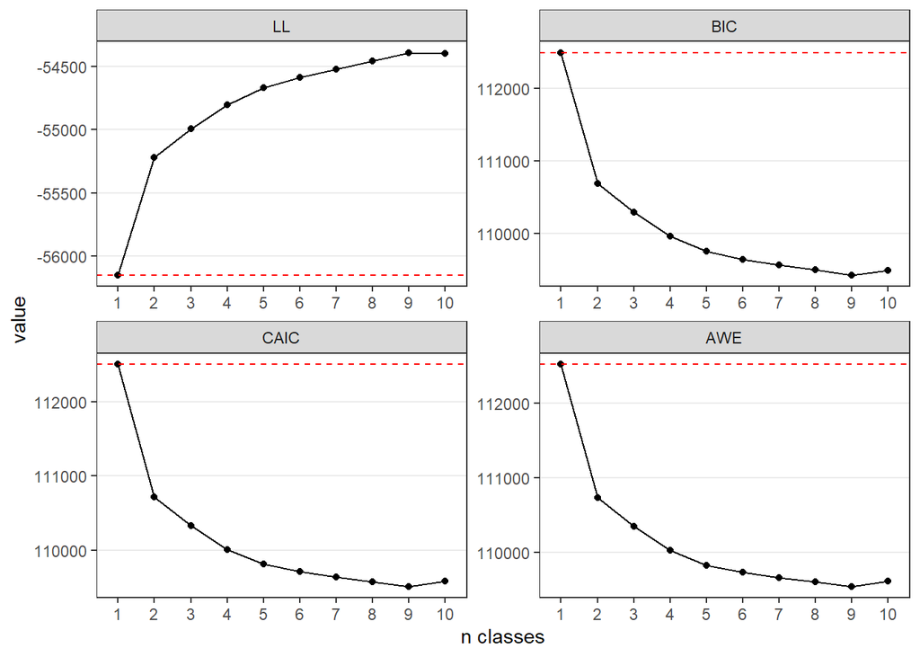

```r
# Elbow plots for information criteria
lpa_enum_elbow(lpa_b_summary, benchmark_stats = lpa_benchmark)
```

Best model for:

**a) Absolute fit** (fewest classes with better LL than benchmark)**:** *2-class*  
**b) Information heuristics** (diminishing gains from elbow plots)**:** *2-class/5-class*  
**c) Adjusted LRTs** (fewest classes not sig improved by additional classes)**:** *4-/5-class*  
**d) Approximate BF** (fewest classes with moderate-strong evidence compared to next model): *9-class*  
**e) Approximate correct model probability:** *9-class*

### Inspection

**Step 6)** View classification diagnostics for candidate models.

```r
# Extract participant level data
lpa_b_rerun <- mm_extract_data(orig_mods = m_lpa_b, orig_output = lpa_b_out,
                               candidate_mods = c(4:5),
                               filepath = "mplus_models/simpview/lpa_comp",
                               rerun = FALSE, optseed = TRUE,
                               one_fit = TRUE)

# Print table, and append bLRT values to main output
# lpa_enum_table(lpa_b_rerun)
lpa_b_summary <- add_bLRT(lpa_b_rerun, lpa_b_summary)
lpa_b_summary %>% kable("pipe")
```

| Specification | Classes | Parameters | LL | BIC | CAIC | AWE | VLMR_p | LMR_p | bLRT_p | BF | cmP_k |
| --- | --- | --- | --- | --- | --- | --- | --- | --- | --- | --- | --- |
| LPA Model B: 1 classes; | 1 | 23 | -56151.25 | 112489.7 | 112512.7 | 112524.2 | NA | NA | NA | NA | 0 |
| LPA Model B: 2 classes; | 2 | 30 | -55222.49 | 110689.1 | 110719.1 | 110734.1 | <0.01 | <0.01 | NA | >100 | 0 |
| LPA Model B: 3 classes; | 3 | 37 | -54995.67 | 110292.4 | 110329.4 | 110347.9 | <0.01 | <0.01 | NA | >100 | 0 |
| LPA Model B: 4 classes; | 4 | 44 | -54802.68 | 109963.4 | 110007.4 | 110029.4 | <0.01 | <0.01 | <0.01 | >100 | 0 |
| LPA Model B: 5 classes; | 5 | 51 | -54670.92 | 109756.9 | 109807.9 | 109833.4 | NA | NA | <0.01 | >100 | 0 |
| LPA Model B: 6 classes; | 6 | 58 | -54588.42 | 109648.9 | 109706.9 | 109735.9 | 0.44 | 0.44 | NA | >100 | 0 |
| LPA Model B: 7 classes; | 7 | 65 | -54521.03 | 109571.1 | 109636.1 | 109668.6 | 0.24 | 0.24 | NA | >100 | 0 |
| LPA Model B: 8 classes; | 8 | 72 | -54457.28 | 109500.5 | 109572.5 | 109608.5 | 0.10 | 0.10 | NA | >100 | 0 |
| LPA Model B: 9 classes; | 9 | 79 | -54391.87 | 109426.7 | 109505.7 | 109545.2 | 0.38 | 0.39 | NA | >100 | 1 |
| LPA Model B: 10 classes; | 10 | 86 | -54396.77 | 109493.4 | 109579.4 | 109622.4 | NA | NA | NA | <0.01 | 0 |

```r
# Compute classification diagnostics
class_diag(lpa_b_rerun)
```

```
## [1] "CLASSIFICATION DIAGNOSTICS FOR  LPA MODEL B: 4 CLASSES;"
## [1] "Entropy: 0.889"
##
## [1] "Average posterior class probability:"
##     1     2     3     4
## 0.717 0.739 0.983 0.789
##
## [1] "Odds of correct classification ratio:"
##  1  2  3  4
## 38 70 12 47
## [1] "Good class separation and assignment accuracy (Nagin, 2005)"
##
## [1] "Model estimated proportion for each class:"
## [1] 0.06188 0.03891 0.82499 0.07421
##
## [1] "Proportion modally assigned to each class:"
## [1] 0.05054 0.03038 0.84604 0.07304
##
## [1] "--------------------------------------------"
##
## [1] "CLASSIFICATION DIAGNOSTICS FOR  LPA MODEL B: 5 CLASSES;"
## [1] "Entropy: 0.827"
##
## [1] "Average posterior class probability:"
##     1     2     3     4     5
## 0.752 0.721 0.955 0.758 0.766
##
## [1] "Odds of correct classification ratio:"
##  1  2  3  4  5
## 77 42  9 18 49
## [1] "Good class separation and assignment accuracy (Nagin, 2005)"
##
## [1] "Model estimated proportion for each class:"
## [1] 0.03789 0.05822 0.69381 0.14740 0.06268
##
## [1] "Proportion modally assigned to each class:"
## [1] 0.03126 0.04733 0.72363 0.13701 0.06077
##
## [1] "--------------------------------------------"
```

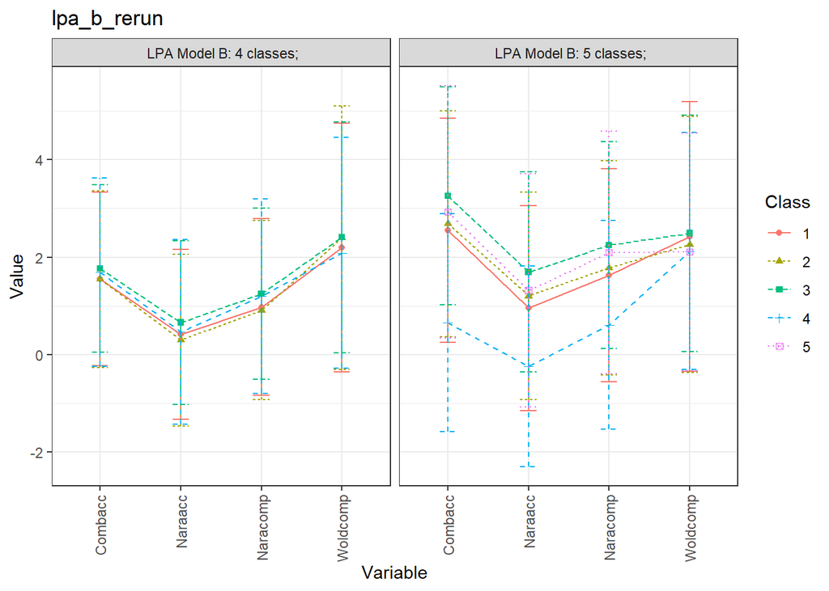

```r
# Plot class means
plotMixtures_simpView(lpa_b_rerun)
```

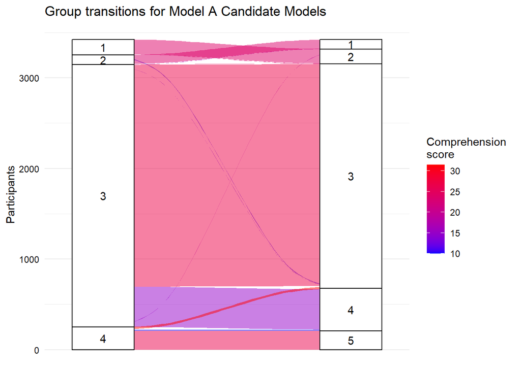

```r
# Inspect transitions
extract_classes(lpa_b_rerun, type = "lpa")
```

Comments:

- **Classification diagnostics:** *Entropy and class separation better for 4-class model, but adequate for 5-class model too.*
- **Interpretability:** *5-class model splits out a lower performing group, which is useful in relation to identifying weaknesses in reading.*
- *Note that the bLRTs of both models produced warnings that a high proportion of draws had a smaller LRT that the observed LRT and not a replicated LL. However, increasing the random starts further is not feasible (already at 1000 250).*

### Selection

**Step 7)** Select final model in class enumeration process, for model specification B.

```r
lpa_b_final_nclass <- 5
lpa_b_final_m <- lpa_b_rerun[2]
```

## Model C: Class-varying, diagonal

**Indicator variances are estimated separately for each class.** **No covariances are estimated.**

### Specification

**Steps 1-3)** Fit series of increasing *k*-class models.

```r
m_lpa_c <- lapply(1:10, function(k) {

  # Update model spec 1: overall model estimates (variances only)
  body <- update(m_lpa_base,
              MODEL = as.formula(sprintf("~ . + '%s %s'", lpa_vars, no_covars)))

  # Create class-level specifications (to include variances only)
  class_spec <- paste0("%c#1% \n ", lpa_vars)
  if (k > 1){
    for (i in 2:k){
      class_spec <- paste0(class_spec, "\n %c#", i, "% \n ", lpa_vars)
    }
  }

  # ...Update model spec 2: class estimates
  body <- update(body,
     TITLE = as.formula(sprintf("~ 'LPA Model C: %d classes;'", k)),
     VARIABLE = as.formula(sprintf("~ 'idvariable = cidb3153; classes = c(%d);'", k)),
     MODEL = as.formula(sprintf("~ . + '%s'", class_spec)))

  # Run model
  mplusModeler(body, sprintf("mplus_models/simpview/lpa_comp/sv_lpa_c_%dclass.dat", k), run = FALSE)
 })
```

Use optseed to re-compute adjusted LRT tests (Lo-Mendell-Rubin; Vuong-Lo-Mendell-Rubin).

```r
# Read in output
lpa_c_out <- readModels(target = "./mplus_models/simpview/lpa_comp", filefilter = "sv_lpa_c_([1-9])")

# Check LMR tests
lpa_c_lmr <- recomp_LMR(orig_mods = m_lpa_c,
                        orig_output = lpa_c_out,
                        mods = c(1:length(lpa_c_out)),
                        #mods = c(10),        # used to specify individual models for re-rerunning
                        #kstarts = "6000 1500",   # used for re-running if necessary
                        filepath = "mplus_models/simpview/lpa_comp",
                        rerun = FALSE
                        )

lpa_enum_table(lpa_c_lmr, LMR_warn = TRUE) %>%
  select(Specification, Classes, LMR_check) %>%
  filter(!is.na(LMR_check))
```

```
##               Specification Classes  LMR_check
## 1   LPA Model C: 2 classes;       2
## 2   LPA Model C: 3 classes;       3
## 3   LPA Model C: 4 classes;       4
## 4   LPA Model C: 5 classes;       5
## 5   LPA Model C: 6 classes;       6
## 6   LPA Model C: 7 classes;       7
## 7   LPA Model C: 8 classes;       8
## 8   LPA Model C: 9 classes;       9
## 9  LPA Model C: 10 classes;      10 Re-run LMR
```

Note that the LMR tests for the 10-class model does not reach the same solutions for the k-1 model as the initial model fitted (tried up to 6000 1500 starts). However, as indicated by the fit indices below, this higher class model is unlikely to be useful.

### Indices

**Steps 4-5)** Extract fit indices, and use to select smaller subset of candidate models.

```r
# Read in output
lpa_c_lmr <- readModels(target = "./mplus_models/simpview/lpa_comp", filefilter = "lpa_c_lmr")

# Print table
lpa_c_summary <- lpa_enum_table(output = lpa_c_lmr)
lpa_c_summary[c(10), c(8,9)] <- NA  # Remove values from non-trusted k-1 comparisons
lpa_c_summary %>% kable("pipe")
```

| Specification | Classes | LL | Parameters | BIC | CAIC | AWE | VLMR_p | LMR_p | BF | cmP_k |
| --- | --- | --- | --- | --- | --- | --- | --- | --- | --- | --- |
| LPA Model C: 1 classes; | 1 | -60382.88 | 17 | 120904.1 | 120921.1 | 120929.6 | NA | NA | NA | 0 |
| LPA Model C: 2 classes; | 2 | -57593.25 | 28 | 115414.4 | 115442.4 | 115456.4 | <0.01 | <0.01 | >100 | 0 |
| LPA Model C: 3 classes; | 3 | -56631.39 | 39 | 113580.2 | 113619.2 | 113638.7 | 0.01 | 0.01 | >100 | 0 |
| LPA Model C: 4 classes; | 4 | -55930.00 | 50 | 112266.9 | 112316.9 | 112341.9 | <0.01 | <0.01 | >100 | 0 |
| LPA Model C: 5 classes; | 5 | -55405.57 | 61 | 111307.6 | 111368.6 | 111399.1 | <0.01 | <0.01 | >100 | 0 |
| LPA Model C: 6 classes; | 6 | -55114.32 | 72 | 110814.6 | 110886.6 | 110922.6 | <0.01 | <0.01 | >100 | 0 |
| LPA Model C: 7 classes; | 7 | -54965.41 | 83 | 110606.3 | 110689.3 | 110730.8 | 0.08 | 0.08 | >100 | 0 |
| LPA Model C: 8 classes; | 8 | -54841.99 | 94 | 110449.0 | 110543.0 | 110590.0 | 0.05 | 0.05 | >100 | 0 |
| LPA Model C: 9 classes; | 9 | -54728.35 | 105 | 110311.2 | 110416.2 | 110468.7 | 0.04 | 0.04 | >100 | 1 |
| LPA Model C: 10 classes; | 10 | -54736.30 | 116 | 110416.6 | 110532.6 | 110590.6 | NA | NA | <0.01 | 0 |

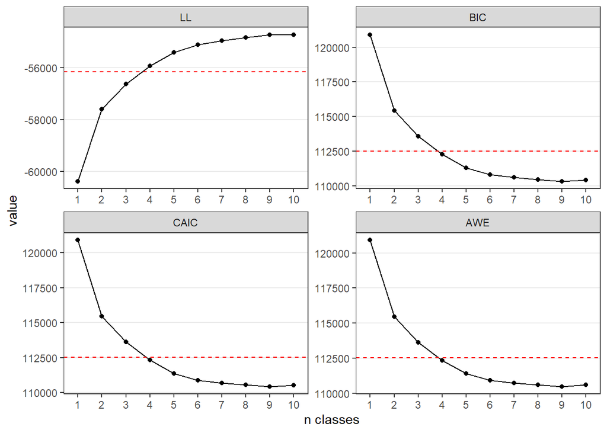

```r
# Elbow plots for information criteria
lpa_enum_elbow(lpa_c_summary, benchmark_stats = lpa_benchmark)
```

Best model for:

**a) Absolute fit** (fewest classes with better LL than benchmark)**:** *4-class*  
**b) Information heuristics** (diminishing gains from elbow plots)**:** 2-/*5-class*  
**c) Adjusted LRTs** (fewest classes not sig improved by additional classes)**:** *6-class*  
**d) Approximate BF** (fewest classes with moderate-strong evidence compared to next model): *9-class*  
**e) Approximate correct model probability:** *9-class*

### Inspection

**Step 6)** View classification diagnostics for candidate models.

```r
# Extract participant level data
lpa_c_rerun <- mm_extract_data(orig_mods = m_lpa_c, orig_output = lpa_c_out,
                               candidate_mods = c(4:6),
                               filepath = "mplus_models/simpview/lpa_comp",
                               rerun = FALSE, optseed = TRUE,
                               one_fit = TRUE)

# Print table, and append bLRT values to main output
lpa_c_summary <- add_bLRT(lpa_c_rerun, lpa_c_summary)
lpa_c_summary %>% kable("pipe")
```

| Specification | Classes | Parameters | LL | BIC | CAIC | AWE | VLMR_p | LMR_p | bLRT_p | BF | cmP_k |
| --- | --- | --- | --- | --- | --- | --- | --- | --- | --- | --- | --- |
| LPA Model C: 1 classes; | 1 | 17 | -60382.88 | 120904.1 | 120921.1 | 120929.6 | NA | NA | NA | NA | 0 |
| LPA Model C: 2 classes; | 2 | 28 | -57593.25 | 115414.4 | 115442.4 | 115456.4 | <0.01 | <0.01 | NA | >100 | 0 |
| LPA Model C: 3 classes; | 3 | 39 | -56631.39 | 113580.2 | 113619.2 | 113638.7 | 0.01 | 0.01 | NA | >100 | 0 |
| LPA Model C: 4 classes; | 4 | 50 | -55930.00 | 112266.9 | 112316.9 | 112341.9 | <0.01 | <0.01 | <0.01 | >100 | 0 |
| LPA Model C: 5 classes; | 5 | 61 | -55405.57 | 111307.6 | 111368.6 | 111399.1 | <0.01 | <0.01 | <0.01 | >100 | 0 |
| LPA Model C: 6 classes; | 6 | 72 | -55114.32 | 110814.6 | 110886.6 | 110922.6 | <0.01 | <0.01 | <0.01 | >100 | 0 |
| LPA Model C: 7 classes; | 7 | 83 | -54965.41 | 110606.3 | 110689.3 | 110730.8 | 0.08 | 0.08 | NA | >100 | 0 |
| LPA Model C: 8 classes; | 8 | 94 | -54841.99 | 110449.0 | 110543.0 | 110590.0 | 0.05 | 0.05 | NA | >100 | 0 |
| LPA Model C: 9 classes; | 9 | 105 | -54728.35 | 110311.2 | 110416.2 | 110468.7 | 0.04 | 0.04 | NA | >100 | 1 |
| LPA Model C: 10 classes; | 10 | 116 | -54736.30 | 110416.6 | 110532.6 | 110590.6 | NA | NA | NA | <0.01 | 0 |

```r
# Compute classification diagnostics
class_diag(lpa_c_rerun)
```

```
## [1] "CLASSIFICATION DIAGNOSTICS FOR  LPA MODEL C: 4 CLASSES;"
## [1] "Entropy: 0.866"
##
## [1] "Average posterior class probability:"
##     1     2     3     4
## 0.909 0.923 0.836 0.949
##
## [1] "Odds of correct classification ratio:"
##  1  2  3  4
## 17 64 89 26
## [1] "Good class separation and assignment accuracy (Nagin, 2005)"
##
## [1] "Model estimated proportion for each class:"
## [1] 0.37377 0.15672 0.05398 0.41553
##
## [1] "Proportion modally assigned to each class:"
## [1] 0.37657 0.15630 0.04879 0.41835
##
## [1] "--------------------------------------------"
##
## [1] "CLASSIFICATION DIAGNOSTICS FOR  LPA MODEL C: 5 CLASSES;"
## [1] "Entropy: 0.853"
##
## [1] "Average posterior class probability:"
##     1     2     3     4     5
## 0.912 0.916 0.886 0.922 0.830
##
## [1] "Odds of correct classification ratio:"
##   1   2   3   4   5
##  34 132  13  33  89
## [1] "Good class separation and assignment accuracy (Nagin, 2005)"
##
## [1] "Model estimated proportion for each class:"
## [1] 0.23595 0.07646 0.37365 0.26218 0.05177
##
## [1] "Proportion modally assigned to each class:"
## [1] 0.23956 0.07566 0.37044 0.26877 0.04557
##
## [1] "--------------------------------------------"
##
## [1] "CLASSIFICATION DIAGNOSTICS FOR  LPA MODEL C: 6 CLASSES;"
## [1] "Entropy: 0.858"
##
## [1] "Average posterior class probability:"
##     1     2     3     4     5     6
## 0.881 0.908 0.957 0.896 0.906 0.843
##
## [1] "Odds of correct classification ratio:"
##   1   2   3   4   5   6
##  13  34 467  31  82 100
## [1] "Good class separation and assignment accuracy (Nagin, 2005)"
##
## [1] "Model estimated proportion for each class:"
## [1] 0.35629 0.22375 0.04549 0.21799 0.10563 0.05085
##
## [1] "Proportion modally assigned to each class:"
## [1] 0.35174 0.22962 0.04616 0.22057 0.10605 0.04587
##
## [1] "--------------------------------------------"
```

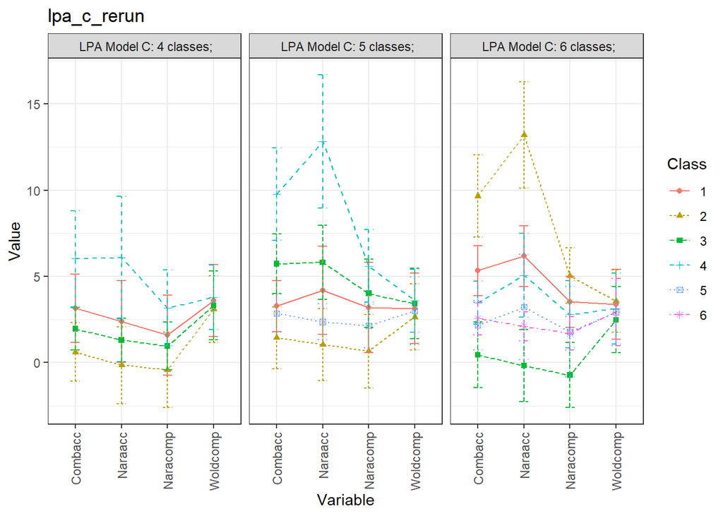

```r
# Plot class means
plotMixtures_simpView(lpa_c_rerun)
```

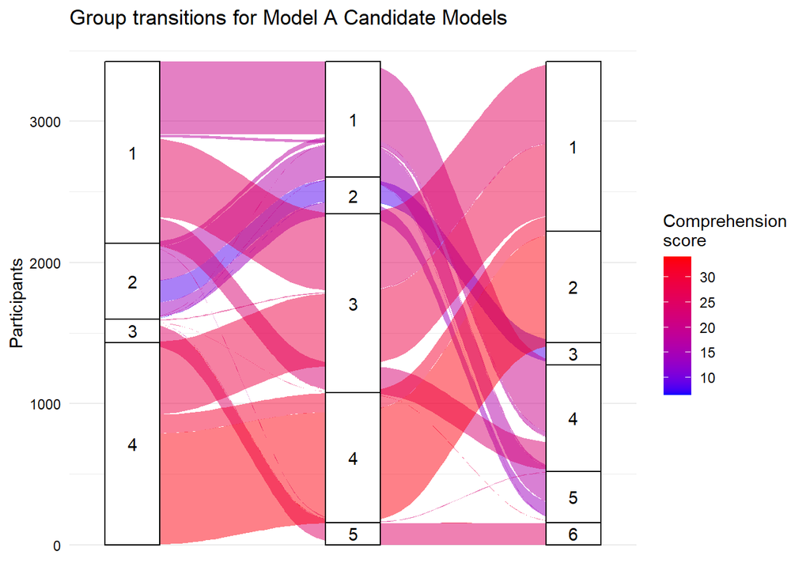

```r
# Inspect transitions
extract_classes(lpa_c_rerun, type = "lpa")
```

Comments:

- **Classification diagnostics:** *All classification diagnostics good, best for lower class models but equivalent*
- **Interpretability:** *Generally dissociated by ability; 5-class+ models better dissociate a higher level of ability, whereas the 4-class model contains fairly close overlapping profiles.*
- *Note that the bLRTs of the 4- and 6-class models produced warnings that a high proportion of draws had a smaller LRT that the observed LRT and not a replicated LL. However, increasing the random starts further is not feasible (already at 1000 250).*

### Selection

**Step 7)** Select final model in class enumeration process, for model specification C.

```r
lpa_c_final_nclass <- 5
lpa_c_final_m <- lpa_c_rerun[2]
```

## Model D: Class-varying (part), unrestricted

**Indicator variances are estimated separately for each class.**

**Covariances are constrained to be equal across classes.**

### Specification

**Steps 1-3)** Fit series of increasing *k*-class models.

```r
m_lpa_d <- lapply(1:10, function(k) {

  # Update model spec 1: overall model estimates (variances and covariances)
  body <- update(m_lpa_base,
              MODEL = as.formula(sprintf("~ . + '%s \n %s '", lpa_vars, lpa_covars)))

  # Create class-level specifications (variances only)
  class_spec <- paste0("%c#1% \n ", lpa_vars)
  if (k > 1){
    for (i in 2:k){
      class_spec <- paste0(class_spec, "\n %c#", i, "% \n ", lpa_vars)
    }
  }

  # ...Update model spec 2: class estimates
  body <- update(body,
     TITLE = as.formula(sprintf("~ 'LPA Model D: %d classes;'", k)),
     VARIABLE = as.formula(sprintf("~ 'idvariable = cidb3153; classes = c(%d);'", k)),
     MODEL = as.formula(sprintf("~ . + '%s'", class_spec)))

  # Run model
  mplusModeler(body, sprintf("mplus_models/simpview/lpa_comp/sv_lpa_d_%dclass.dat", k), run = FALSE)
 })
```

Use optseed to re-compute adjusted LRT tests (Lo-Mendell-Rubin; Vuong-Lo-Mendell-Rubin).

```r
# Read in output
lpa_d_out <- readModels(target = "./mplus_models/simpview/lpa_comp", filefilter = "sv_lpa_d_([1-9])")

# Check LMR tests
lpa_d_lmr <- recomp_LMR(orig_mods = m_lpa_d,
                        orig_output = lpa_d_out,
                        mods = c(1:length(lpa_d_out)),
                        #mods = c(7,9,10),        # used to specify individual models for re-rerunning
                        #kstarts = "4000 1000",   # used for re-running if necessary
                        filepath = "mplus_models/simpview/lpa_comp",
                        rerun = FALSE
                        )

lpa_enum_table(lpa_d_lmr, LMR_warn = TRUE) %>%
  select(Specification, Classes, LMR_check) %>%
  filter(!is.na(LMR_check))
```

```
##               Specification Classes LMR_check
## 1   LPA Model D: 2 classes;       2
## 2   LPA Model D: 3 classes;       3
## 3   LPA Model D: 4 classes;       4
## 4   LPA Model D: 5 classes;       5
## 5   LPA Model D: 6 classes;       6
## 6   LPA Model D: 7 classes;       7
## 7   LPA Model D: 8 classes;       8
## 8   LPA Model D: 9 classes;       9
## 9  LPA Model D: 10 classes;      10
```

### Indices

**Steps 4-5)** Extract fit indices, and use to select smaller subset of candidate models.

```r
# Read in output
lpa_d_lmr <- readModels(target = "./mplus_models/simpview/lpa_comp", filefilter = "lpa_d_lmr")

# Print table
lpa_d_summary <- lpa_enum_table(output = lpa_d_lmr)
lpa_d_summary %>% kable("pipe")
```

| Specification | Classes | LL | Parameters | BIC | CAIC | AWE | VLMR_p | LMR_p | BF | cmP_k |
| --- | --- | --- | --- | --- | --- | --- | --- | --- | --- | --- |
| LPA Model D: 1 classes; | 1 | -56151.25 | 23 | 112489.7 | 112512.7 | 112524.2 | NA | NA | NA | 0 |
| LPA Model D: 2 classes; | 2 | -55222.09 | 34 | 110720.9 | 110754.9 | 110771.9 | <0.01 | <0.01 | >100 | 0 |
| LPA Model D: 3 classes; | 3 | -54922.88 | 45 | 110212.0 | 110257.0 | 110279.5 | <0.01 | <0.01 | >100 | 0 |
| LPA Model D: 4 classes; | 4 | -54722.61 | 56 | 109901.0 | 109957.0 | 109985.0 | <0.01 | <0.01 | >100 | 0 |
| LPA Model D: 5 classes; | 5 | -54558.06 | 67 | 109661.4 | 109728.4 | 109761.9 | <0.01 | <0.01 | >100 | 0 |
| LPA Model D: 6 classes; | 6 | -54469.91 | 78 | 109574.6 | 109652.6 | 109691.6 | 0.25 | 0.25 | >100 | 0 |
| LPA Model D: 7 classes; | 7 | -54372.97 | 89 | 109470.2 | 109559.2 | 109603.8 | 0.26 | 0.26 | >100 | 0 |
| LPA Model D: 8 classes; | 8 | -54288.88 | 100 | 109391.6 | 109491.6 | 109541.6 | 0.07 | 0.07 | >100 | 0 |
| LPA Model D: 9 classes; | 9 | -54202.41 | 111 | 109308.2 | 109419.2 | 109474.7 | <0.01 | <0.01 | >100 | 0 |
| LPA Model D: 10 classes; | 10 | -54143.52 | 122 | 109279.9 | 109401.9 | 109462.9 | 0.05 | 0.05 | >100 | 1 |

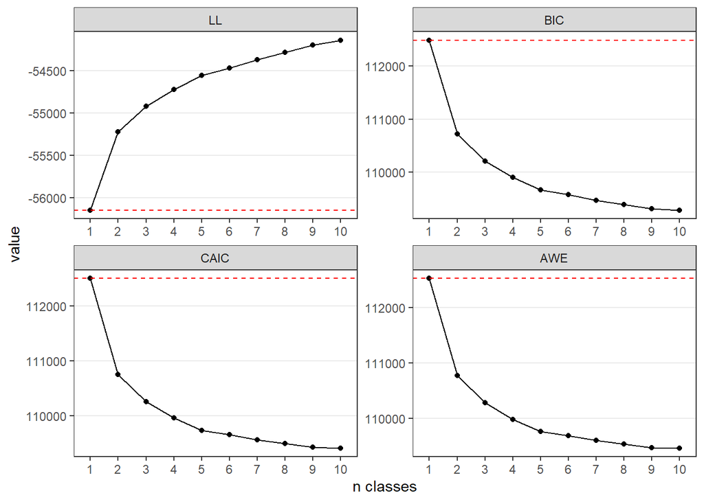

```r
# Elbow plots for information criteria
lpa_enum_elbow(lpa_d_summary, benchmark_stats = lpa_benchmark)
```

Best model for:

**a) Absolute fit** (fewest classes with better LL than benchmark)**:** *2-class*  
**b) Information heuristics** (diminishing gains from elbow plots)**:** *2-/3-/5-class*  
**c) Adjusted LRTs** (fewest classes not sig improved by additional classes)**:** *5-class*  
**d) Approximate BF** (fewest classes with moderate-strong evidence compared to next model): *10-class/NA*  
**e) Approximate correct model probability:** *10-class/NA*

### Inspection

**Step 6)** View classification diagnostics for candidate models.

```r
# Extract participant level data
lpa_d_rerun <- mm_extract_data(orig_mods = m_lpa_d, orig_output = lpa_d_out,
                               candidate_mods = c(3:5),
                               filepath = "mplus_models/simpview/lpa_comp",
                               rerun = FALSE, optseed = TRUE,
                               one_fit = TRUE)

# Print table, and append bLRT values to main output
lpa_d_summary <- add_bLRT(lpa_d_rerun, lpa_d_summary)
lpa_d_summary %>% kable("pipe")
```

| Specification | Classes | Parameters | LL | BIC | CAIC | AWE | VLMR_p | LMR_p | bLRT_p | BF | cmP_k |
| --- | --- | --- | --- | --- | --- | --- | --- | --- | --- | --- | --- |
| LPA Model D: 1 classes; | 1 | 23 | -56151.25 | 112489.7 | 112512.7 | 112524.2 | NA | NA | NA | NA | 0 |
| LPA Model D: 2 classes; | 2 | 34 | -55222.09 | 110720.9 | 110754.9 | 110771.9 | <0.01 | <0.01 | NA | >100 | 0 |
| LPA Model D: 3 classes; | 3 | 45 | -54922.88 | 110212.0 | 110257.0 | 110279.5 | <0.01 | <0.01 | <0.01 | >100 | 0 |
| LPA Model D: 4 classes; | 4 | 56 | -54722.61 | 109901.0 | 109957.0 | 109985.0 | <0.01 | <0.01 | <0.01 | >100 | 0 |
| LPA Model D: 5 classes; | 5 | 67 | -54558.06 | 109661.4 | 109728.4 | 109761.9 | <0.01 | <0.01 | <0.01 | >100 | 0 |
| LPA Model D: 6 classes; | 6 | 78 | -54469.91 | 109574.6 | 109652.6 | 109691.6 | 0.25 | 0.25 | NA | >100 | 0 |
| LPA Model D: 7 classes; | 7 | 89 | -54372.97 | 109470.2 | 109559.2 | 109603.8 | 0.26 | 0.26 | NA | >100 | 0 |
| LPA Model D: 8 classes; | 8 | 100 | -54288.88 | 109391.6 | 109491.6 | 109541.6 | 0.07 | 0.07 | NA | >100 | 0 |
| LPA Model D: 9 classes; | 9 | 111 | -54202.41 | 109308.2 | 109419.2 | 109474.7 | <0.01 | <0.01 | NA | >100 | 0 |
| LPA Model D: 10 classes; | 10 | 122 | -54143.52 | 109279.9 | 109401.9 | 109462.9 | 0.05 | 0.05 | NA | >100 | 1 |

```r
# Compute classification diagnostics
class_diag(lpa_d_rerun)
```

```
## [1] "CLASSIFICATION DIAGNOSTICS FOR  LPA MODEL D: 3 CLASSES;"
## [1] "Entropy: 0.83"
##
## [1] "Average posterior class probability:"
##     1     2     3
## 0.833 0.815 0.959
##
## [1] "Odds of correct classification ratio:"
##  1  2  3
## 20 63  9
## [1] "Good class separation and assignment accuracy (Nagin, 2005)"
##
## [1] "Model estimated proportion for each class:"
## [1] 0.20318 0.06559 0.73123
##
## [1] "Proportion modally assigned to each class:"
## [1] 0.19807 0.05901 0.74292
##
## [1] "--------------------------------------------"
##
## [1] "CLASSIFICATION DIAGNOSTICS FOR  LPA MODEL D: 4 CLASSES;"
## [1] "Entropy: 0.839"
##
## [1] "Average posterior class probability:"
##     1     2     3     4
## 0.816 0.724 0.959 0.839
##
## [1] "Odds of correct classification ratio:"
##   1   2   3   4
##  19  40  10 112
## [1] "Good class separation and assignment accuracy (Nagin, 2005)"
##
## [1] "Model estimated proportion for each class:"
## [1] 0.18722 0.06087 0.70764 0.04428
##
## [1] "Proportion modally assigned to each class:"
## [1] 0.18054 0.04966 0.72772 0.04207
##
## [1] "--------------------------------------------"
##
## [1] "CLASSIFICATION DIAGNOSTICS FOR  LPA MODEL D: 5 CLASSES;"
## [1] "Entropy: 0.831"
##
## [1] "Average posterior class probability:"
##     1     2     3     4     5
## 0.734 0.802 0.773 0.762 0.950
##
## [1] "Odds of correct classification ratio:"
##  1  2  3  4  5
## 44 19 87 53  9
## [1] "Good class separation and assignment accuracy (Nagin, 2005)"
##
## [1] "Model estimated proportion for each class:"
## [1] 0.05872 0.17746 0.03772 0.05740 0.66870
##
## [1] "Proportion modally assigned to each class:"
## [1] 0.04879 0.17032 0.03243 0.05551 0.69296
##
## [1] "--------------------------------------------"
```

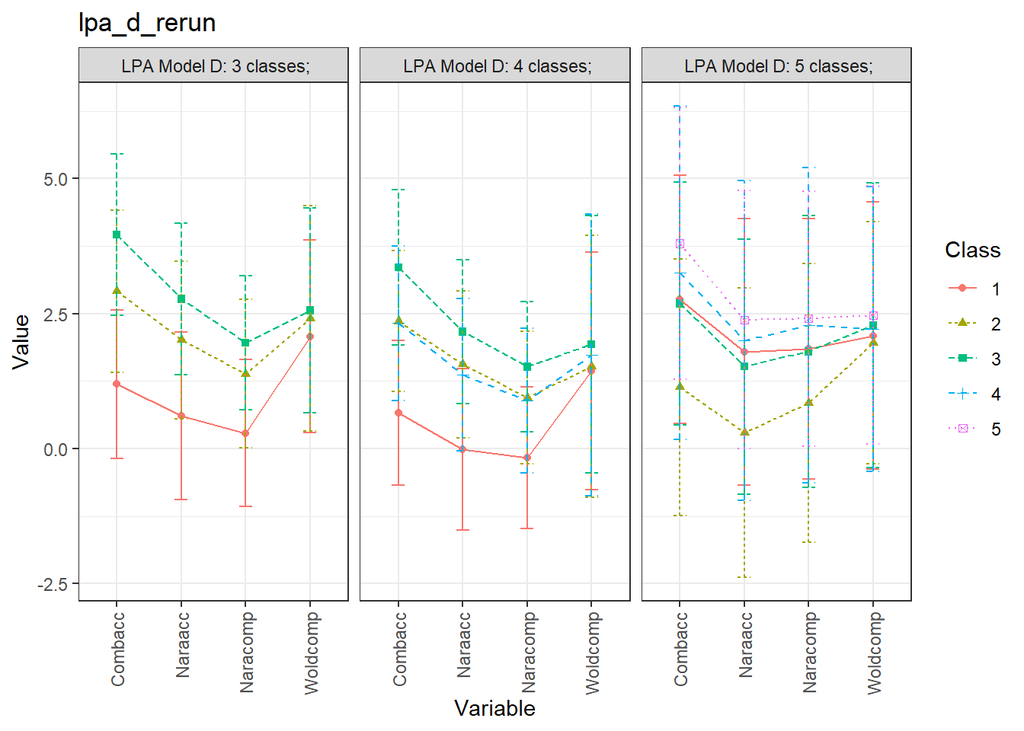

```r
# Plot class means
plotMixtures_simpView(lpa_d_rerun)
```

[figure not shown]

```r
# Inspect transitions
extract_classes(lpa_d_rerun, type = "lpa")
```

Comments:

- **Classification diagnostics:** *Very similar entropy across models; average posterior class probability very good for 3-class model, lower for additional classes.*
- **Interpretability:** *As previous models, profiles largely dissociated by ability. Additional classes beyond 3-class model are small and not well differentiated. The simplest model is preferred here.*
- *Note that the bLRTs of all models produced warnings that a high proportion of draws had a smaller LRT that the observed LRT and not a replicated LL. However, increasing the random starts further is not feasible (already at 1000 250).*

### Selection

**Step 7)** Select final model in class enumeration process, for model specification D.

```r
lpa_d_final_nclass <- 3
lpa_d_final_m <- lpa_d_rerun[1]
```

## Model E: Class-varying (full), unrestricted

**All variances and covariances can vary between clusters.**

### Specification

**Steps 1-3)** Fit series of increasing *k*-class models.

```r
m_lpa_e <- lapply(1:10, function(k) {

  # Update model spec 1: overall model estimates (variances and covariances)
  body <- update(m_lpa_base,
              MODEL = as.formula(sprintf("~ . + '%s \n %s '", lpa_vars, lpa_covars)))

  # Create class-level specifications (variances and covariances)
  class_spec <- paste0("%c#1% \n ", lpa_vars,  lpa_covars)
  if (k > 1){
    for (i in 2:k){
      class_spec <- paste0(class_spec, "\n %c#", i, "% \n ", lpa_vars, lpa_covars)
    }
  }

  # ...Update model spec 2: class estimates
  body <- update(body,
     TITLE = as.formula(sprintf("~ 'LPA Model E: %d classes;'", k)),
     VARIABLE = as.formula(sprintf("~ 'idvariable = cidb3153; classes = c(%d);'", k)),
     MODEL = as.formula(sprintf("~ . + '%s'", class_spec)))

  # Run model
  mplusModeler(body, sprintf("mplus_models/simpview/lpa_comp/sv_lpa_e_%dclass.dat", k), run = FALSE)
 })
```

Use optseed to re-compute adjusted LRT tests (Lo-Mendell-Rubin; Vuong-Lo-Mendell-Rubin).

```r
# Read in output
lpa_e_out <- readModels(target = "./mplus_models/simpview/lpa_comp", filefilter = "sv_lpa_e_([1-9])")

# Check LMR tests
lpa_e_lmr <- recomp_LMR(orig_mods = m_lpa_e,
                        orig_output = lpa_e_out,
                        mods = c(1:length(lpa_e_out)),
                        #mods = c(10),        # used to specify individual models for re-rerunning
                        #kstarts = "6000 1500",  # used for re-running if necessary
                        filepath = "mplus_models/simpview/lpa_comp",
                        rerun = FALSE
                        )

lpa_enum_table(lpa_e_lmr, LMR_warn = TRUE) %>%
  select(Specification, Classes, LMR_check) %>%
  filter(!is.na(LMR_check))
```

```
##              Specification Classes  LMR_check
## 1  LPA Model E: 2 classes;       2
## 2  LPA Model E: 3 classes;       3
## 3  LPA Model E: 4 classes;       4
## 4  LPA Model E: 5 classes;       5
## 5  LPA Model E: 6 classes;       6
## 6  LPA Model E: 7 classes;       7
## 7  LPA Model E: 8 classes;       8 Re-run LMR
## 8  LPA Model E: 9 classes;       9
```

Note that the LMR tests for the 8-class model does not reach the same solutions for the k-1 model as the initial model fitted (tried up to 6000 1500 starts). The 10-class model also failed to estimate the K-1 model, and so the LMR test was not computed. As indicated by the fit indices below, these models are highly unlikely to be useful, and so we did not pursue the issues further.

### Indices

**Steps 4-5)** Extract fit indices, and use to select smaller subset of candidate models.

```r
# Read in output
lpa_e_lmr <- readModels(target = "./mplus_models/simpview/lpa_comp", filefilter = "(lpa_e_lmr_)([1-9])")

# Print table
lpa_e_summary <- lpa_enum_table(output = lpa_e_lmr)
lpa_e_summary[c(8,10), c(8,9)] <- NA  # Remove values from non-trusted models
lpa_e_summary
```

```
##                Specification Classes        LL Parameters      BIC     CAIC
## 1    LPA Model E: 1 classes;       1 -56151.25         23 112489.7 112512.7
## 2    LPA Model E: 2 classes;       2 -55212.87         40 110751.3 110791.3
## 3    LPA Model E: 3 classes;       3 -54753.05         57 109970.0 110027.0
## 4    LPA Model E: 4 classes;       4 -54528.52         74 109659.3 109733.3
## 5    LPA Model E: 5 classes;       5 -54325.78         91 109392.1 109483.1
## 6    LPA Model E: 6 classes;       6 -54154.00        108 109186.9 109294.9
## 7    LPA Model E: 7 classes;       7 -54075.40        125 109168.1 109293.1
## 8    LPA Model E: 8 classes;       8 -54036.32        142 109228.3 109370.3
## 9    LPA Model E: 9 classes;       9 -54010.25        159 109314.5 109473.5
## 10  LPA Model E: 10 classes;      10 -53987.78        176 109407.9 109583.9
##         AWE VLMR_p LMR_p    BF cmP_k
## 1  112524.2   <NA>  <NA>  <NA>     0
## 2  110811.3  <0.01 <0.01  >100     0
## 3  110055.5  <0.01 <0.01  >100     0
## 4  109770.3  <0.01 <0.01  >100     0
## 5  109528.6   0.01  0.01  >100     0
## 6  109348.9  <0.01 <0.01  >100     0
## 7  109355.6   0.48  0.48  >100     1
## 8  109441.3   <NA>  <NA> <0.01     0
## 9  109553.0   0.74  0.74 <0.01     0
## 10 109671.9   <NA>  <NA> <0.01     0
```

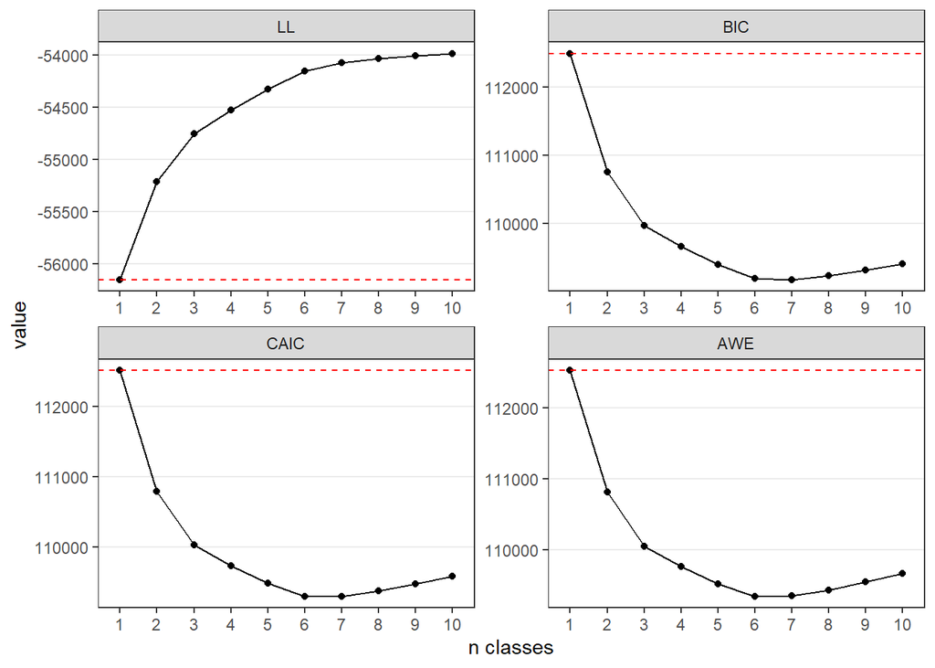

```r
# Elbow plots for information criteria
lpa_enum_elbow(lpa_e_summary, benchmark_stats = lpa_benchmark)
```

Best model for:

**a) Absolute fit** (fewest classes with better LL than benchmark)**:** *2-class*  
**b) Information heuristics** (diminishing gains from elbow plots)**:** *3-class*  
**c) Adjusted LRTs** (fewest classes not sig improved by additional classes)**:** *6-class*  
**d) Approximate BF** (fewest classes with moderate-strong evidence compared to next model): *7-class*  
**e) Approximate correct model probability:** *7-class*

### Inspection

**Step 6)** View classification diagnostics for candidate models.

```r
# Extract participant level data
lpa_e_rerun <- mm_extract_data(orig_mods = m_lpa_e, orig_output = lpa_e_out,
                               candidate_mods = c(3:6),
                               filepath = "mplus_models/simpview/lpa_comp",
                               rerun = FALSE, optseed = TRUE,
                               one_fit = TRUE)

# Print table, and append bLRT values to main output
#lpa_enum_table(lpa_e_rerun)
lpa_e_summary <- add_bLRT(lpa_e_rerun, lpa_e_summary)
lpa_e_summary %>% kable("pipe")
```

| Specification | Classes | Parameters | LL | BIC | CAIC | AWE | VLMR_p | LMR_p | bLRT_p | BF | cmP_k |
| --- | --- | --- | --- | --- | --- | --- | --- | --- | --- | --- | --- |
| LPA Model E: 1 classes; | 1 | 23 | -56151.25 | 112489.7 | 112512.7 | 112524.2 | NA | NA | NA | NA | 0 |
| LPA Model E: 2 classes; | 2 | 40 | -55212.87 | 110751.3 | 110791.3 | 110811.3 | <0.01 | <0.01 | NA | >100 | 0 |
| LPA Model E: 3 classes; | 3 | 57 | -54753.05 | 109970.0 | 110027.0 | 110055.5 | <0.01 | <0.01 | <0.01 | >100 | 0 |
| LPA Model E: 4 classes; | 4 | 74 | -54528.52 | 109659.3 | 109733.3 | 109770.3 | <0.01 | <0.01 | <0.01 | >100 | 0 |
| LPA Model E: 5 classes; | 5 | 91 | -54325.78 | 109392.1 | 109483.1 | 109528.6 | 0.01 | 0.01 | <0.01 | >100 | 0 |
| LPA Model E: 6 classes; | 6 | 108 | -54154.00 | 109186.9 | 109294.9 | 109348.9 | <0.01 | <0.01 | <0.01 | >100 | 0 |
| LPA Model E: 7 classes; | 7 | 125 | -54075.40 | 109168.1 | 109293.1 | 109355.6 | 0.48 | 0.48 | NA | >100 | 1 |
| LPA Model E: 8 classes; | 8 | 142 | -54036.32 | 109228.3 | 109370.3 | 109441.3 | NA | NA | NA | <0.01 | 0 |
| LPA Model E: 9 classes; | 9 | 159 | -54010.25 | 109314.5 | 109473.5 | 109553.0 | 0.74 | 0.74 | NA | <0.01 | 0 |
| LPA Model E: 10 classes; | 10 | 176 | -53987.78 | 109407.9 | 109583.9 | 109671.9 | NA | NA | NA | <0.01 | 0 |

```r
# Compute classification diagnostics
class_diag(lpa_e_rerun)
```

```
## [1] "CLASSIFICATION DIAGNOSTICS FOR  LPA MODEL E: 3 CLASSES;"
## [1] "Entropy: 0.787"
##
## [1] "Average posterior class probability:"
##     1     2     3
## 0.887 0.929 0.815
##
## [1] "Odds of correct classification ratio:"
##  1  2  3
## 11 13 59
## [1] "Good class separation and assignment accuracy (Nagin, 2005)"
##
## [1] "Model estimated proportion for each class:"
## [1] 0.42767 0.50293 0.06940
##
## [1] "Proportion modally assigned to each class:"
## [1] 0.41981 0.51738 0.06281
##
## [1] "--------------------------------------------"
##
## [1] "CLASSIFICATION DIAGNOSTICS FOR  LPA MODEL E: 4 CLASSES;"
## [1] "Entropy: 0.696"
##
## [1] "Average posterior class probability:"
##     1     2     3     4
## 0.808 0.883 0.821 0.786
##
## [1] "Odds of correct classification ratio:"
##  1  2  3  4
##  6 23 62  9
## [1] "Good class separation and assignment accuracy (Nagin, 2005)"
##
## [1] "Model estimated proportion for each class:"
## [1] 0.39750 0.24383 0.06845 0.29022
##
## [1] "Proportion modally assigned to each class:"
## [1] 0.41017 0.26351 0.06281 0.26351
##
## [1] "--------------------------------------------"
##
```

[output cut: 24 more lines]

```
##     1     2     3     4     5     6
## 0.877 0.747 0.801 0.789 0.792 0.744
##
## [1] "Odds of correct classification ratio:"
##  1  2  3  4  5  6
## 24 75 71  7 10 47
## [1] "Good class separation and assignment accuracy (Nagin, 2005)"
##
## [1] "Model estimated proportion for each class:"
## [1] 0.22888 0.03794 0.05375 0.34897 0.27262 0.05784
##
## [1] "Proportion modally assigned to each class:"
## [1] 0.24890 0.03009 0.05551 0.36226 0.25358 0.04966
##
## [1] "--------------------------------------------"
```

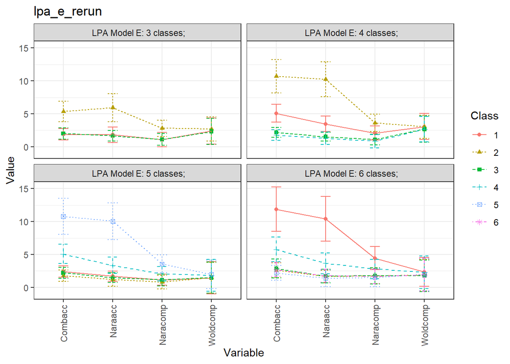

```r
# Plot class means
plotMixtures_simpView(lpa_e_rerun)
```

[figure not shown]

```r
# Inspect transitions
extract_classes(lpa_e_rerun, type = "lpa")
```

Comments:

- **Classification diagnostics:** *Entropy relatively low in all models (but acceptable); lowest average posterior class assignment prob similar across models.*
- **Interpretability:** *The addition of a 4th class separates out a profile with higher overall ability, but further classes do not look well dissociated (e.g., 5-class model - splits average performance into 2 small overlapping classes, would not be easy to label).*
- *Note that the bLRTs of all models produced warnings that a high proportion of draws had a smaller LRT that the observed LRT and not a replicated LL. However, increasing the random starts further is not feasible (already at 1000 250).*

### Selection

**Step 7)** Select final model in class enumeration process, for model specification E.

```r
lpa_e_final_nclass <- 4
lpa_e_final_m <- lpa_e_rerun[2]
```

# Best models

**Aim: Inspect the 5 best candidate models and select the best overall model**

## Final candidates

Use the 5 best candidate models identified above to recalculate the approximate correct model probability, and re-inspect the classification diagnostics of each.

```r
# Select best models
best_fits <- c(lpa_a_final_m, lpa_b_final_m, lpa_c_final_m, lpa_d_final_m, lpa_e_final_m)

# Compute cMP for each
best_summaries <- lpa_enum_table(best_fits) %>%
  select(-c(VLMR_p, LMR_p, BF)) %>%
  rename(cmP_best = cmP_k) %>%
  arrange(Specification)
best_summaries %>% kable("pipe")
```

| Specification | Classes | LL | Parameters | BIC | CAIC | AWE | cmP_best |
| --- | --- | --- | --- | --- | --- | --- | --- |
| LPA Model A: 5 classes; | 5 | -55766.09 | 45 | 111898.4 | 111943.4 | 111965.9 | 0 |
| LPA Model B: 5 classes; | 5 | -54670.92 | 51 | 109756.9 | 109807.9 | 109833.4 | 0 |
| LPA Model C: 5 classes; | 5 | -55405.57 | 61 | 111307.6 | 111368.6 | 111399.1 | 0 |
| LPA Model D: 3 classes; | 3 | -54922.88 | 45 | 110212.0 | 110257.0 | 110279.5 | 0 |
| LPA Model E: 4 classes; | 4 | -54528.52 | 74 | 109659.3 | 109733.3 | 109770.3 | 1 |

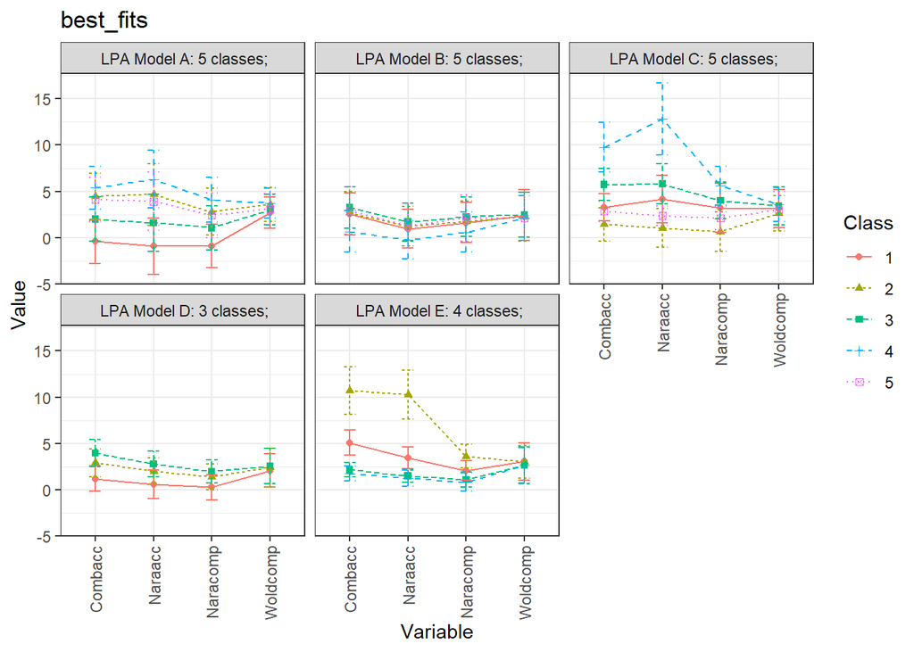

```r
best_cmP <- best_summaries %>%
  select(Specification, Classes, cmP_best)

# Compute classification diagnostics
class_diag(best_fits)

# Plot class means
plotMixtures_simpView(best_fits)
```

[output not shown]

## All model summaries

Combine all model fit indices into a single table, highlighting the best candidate models. Given the vast majority of bLRT values were inaccurate, remove these from the summary table.

```r
# Combine all summary tables
lpa_all_summaries <- rbind(lpa_a_summary, lpa_b_summary, lpa_c_summary,
                           lpa_d_summary, lpa_e_summary) %>%
  filter(Classes <= 8)

# Extract number of classes modelled in class enumeration process
k_classes_modelled <- max(lpa_all_summaries$Classes, na.rm = TRUE)

# Specify table row for selected models for each spec
a_row <- lpa_a_final_nclass
b_row <- (1*k_classes_modelled) + lpa_b_final_nclass
c_row <- (2*k_classes_modelled) + lpa_c_final_nclass
d_row <- (3*k_classes_modelled) + lpa_d_final_nclass
e_row <- (4*k_classes_modelled) + lpa_e_final_nclass

# Format table, highlight class model of best fit in each specification
lpa_all_summaries %>%
  left_join(best_cmP, by = c("Specification", "Classes")) %>%
  mutate(Specification = " ") %>%
  mutate(across(where(is.numeric), round, 2)) %>%
  mutate(VLMR_p = ifelse(VLMR_p == 0, "<0.01", VLMR_p),
         LMR_p = ifelse(LMR_p == 0, "<0.01", LMR_p),
         bLRT_p = ifelse(bLRT_p == 0, "<0.01", bLRT_p),
         BF = ifelse(BF == 0.00, "<0.01",
                     ifelse(BF > 100, ">100", BF)),
         cmP_k = ifelse(cmP_k == 0, "<0.01",
                      ifelse(cmP_k == 1, ">0.99", cmP_k))) %>%
  select(-bLRT_p) %>%  # remove bLRT tests
  replace(is.na(.), "-") %>%
  kbl(align = c("l", "c", "r", "c", "r", "r","r","r","r","r","r")) %>%
  kable_classic(html_font = "Cambria") %>%
  pack_rows(index = c("Model A" = k_classes_modelled, "Model B" = k_classes_modelled, "Model C" = k_classes_modelled, "Model D" = k_classes_modelled, "Model E" = k_classes_modelled)) %>%
  row_spec(1, align = "c") %>%
  row_spec(9, background = "#F0F0F0") %>%
  row_spec(c(a_row, b_row, c_row, d_row, e_row), bold = T)  # edit for row numbers of selected models within each model spec
```

Specification

Classes

Parameters

LL

BIC

CAIC

AWE

VLMR_p

LMR_p

BF

cmP_k

cmP_best

**Model A**

1

17

-60382.88

120904.1

120921.1

120929.6

<0.01

2

24

-57767.55

115730.4

115754.4

115766.4

<0.01

<0.01

>100

<0.01

3

31

-56707.57

113667.4

113698.4

113713.9

<0.01

<0.01

>100

<0.01

4

38

-56171.22

112651.7

112689.7

112708.7

<0.01

<0.01

>100

<0.01

5

45

-55766.09

111898.4

111943.4

111965.9

<0.01

<0.01

>100

<0.01

0

6

52

-55493.25

111409.7

111461.7

111487.7

0.19

0.19

>100

<0.01

7

59

-55281.56

111043.3

111102.3

111131.8

0.41

0.42

>100

<0.01

8

66

-55099.07

110735.3

110801.3

110834.3

0.19

0.20

>100

<0.01

**Model B**

1

23

-56151.25

112489.7

112512.7

112524.2

<0.01

2

30

-55222.49

110689.1

110719.1

110734.1

<0.01

<0.01

>100

<0.01

3

37

-54995.67

110292.4

110329.4

110347.9

<0.01

<0.01

>100

<0.01

4

44

-54802.68

109963.4

110007.4

110029.4

<0.01

<0.01

>100

<0.01

5

51

-54670.92

109756.9

109807.9

109833.4

>100

<0.01

0

6

58

-54588.42

109648.9

109706.9

109735.9

0.44

0.44

>100

<0.01

7

65

-54521.03

109571.1

109636.1

109668.6

0.24

0.24

>100

<0.01

8

72

-54457.28

109500.5

109572.5

109608.5

0.10

0.10

>100

<0.01

**Model C**

1

17

-60382.88

120904.1

120921.1

120929.6

<0.01

2

28

-57593.25

115414.4

115442.4

115456.4

<0.01

<0.01

>100

<0.01

3

39

-56631.39

113580.2

113619.2

113638.7

0.01

0.01

>100

<0.01

4

50

-55930.00

112266.9

112316.9

112341.9

<0.01

<0.01

>100

<0.01

5

61

-55405.57

111307.6

111368.6

111399.1

<0.01

<0.01

>100

<0.01

0

6

72

-55114.32

110814.6

110886.6

110922.6

<0.01

<0.01

>100

<0.01

7

83

-54965.41

110606.3

110689.3

110730.8

0.08

0.08

>100

<0.01

8

94

-54841.99

110449.0

110543.0

110590.0

0.05

0.05

>100

<0.01

**Model D**

1

23

-56151.25

112489.7

112512.7

112524.2

<0.01

2

34

-55222.09

110720.9

110754.9

110771.9

<0.01

<0.01

>100

<0.01

3

45

-54922.88

110212.0

110257.0

110279.5

<0.01

<0.01

>100

<0.01

0

4

56

-54722.61

109901.0

109957.0

109985.0

<0.01

<0.01

>100

<0.01

5

67

-54558.06

109661.4

109728.4

109761.9

<0.01

<0.01

>100

<0.01

6

78

-54469.91

109574.6

109652.6

109691.6

0.25

0.25

>100

<0.01

7

89

-54372.97

109470.2

109559.2

109603.8

0.26

0.26

>100

<0.01

8

100

-54288.88

109391.6

109491.6

109541.6

0.07

0.07

>100

<0.01

**Model E**

1

23

-56151.25

112489.7

112512.7

112524.2

<0.01

2

40

-55212.87

110751.3

110791.3

110811.3

<0.01

<0.01

>100

<0.01

3

57

-54753.05

109970.0

110027.0

110055.5

<0.01

<0.01

>100

<0.01

4

74

-54528.52

109659.3

109733.3

109770.3

<0.01

<0.01

>100

<0.01

1

5

91

-54325.78

109392.1

109483.1

109528.6

0.01

0.01

>100

<0.01

6

108

-54154.00

109186.9

109294.9

109348.9

<0.01

<0.01

>100

<0.01

7

125

-54075.40

109168.1

109293.1

109355.6

0.48

0.48

>100

>0.99

8

142

-54036.32

109228.3

109370.3

109441.3

<0.01

<0.01

```r
# Save table as pdf for later viewing
# save_kable(table_all, file = "../output/tables/SimpView_lpa_all_modelfit.pdf")
```

Combine all fit indices into a single plot.

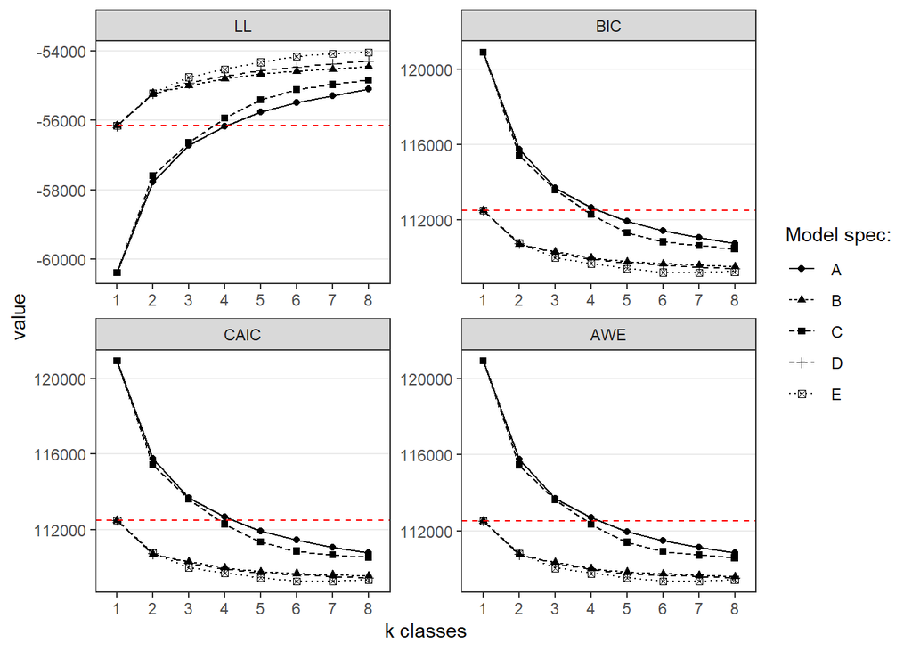

```r
# Grouped elbow plots
lpa_all_summaries %>%
    mutate(model_spec = substr(Specification, 11, 12)) %>%
    select(model_spec, Classes, LL, BIC, CAIC, AWE) %>%
    pivot_longer(LL:AWE, names_to = "statistic", values_to = "value") %>%
    mutate(statistic_relevel = factor(statistic, levels = c("LL", "BIC", "CAIC", "AWE"))) %>%
    ggplot(aes(x = as.factor(Classes), y = value)) +
    geom_point(aes(shape = model_spec)) +
    geom_line(aes(group = model_spec, linetype = model_spec)) +
    xlab("k classes") +
    theme_bw() +
    theme(panel.grid.major.x = element_blank(),
          panel.grid.minor.y = element_blank()) +
    geom_hline(data = lpa_benchmark, aes(yintercept = benchmark), linetype = "dashed", colour = "red") +
    facet_wrap(statistic_relevel ~., scales = "free") +
    labs(shape = "Model spec:", linetype = "Model spec:")
```

```r
# save out for easier viewing
ggsave("../output/figures/SimpView_lpa_all_indices.png", dpi = 600, width = 7, height = 4, units = "in")
```

## Final model

*Models A and C (no covariances) showed much poorer fit to the data than other model specifications. This makes theoretical sense given that we include multiple measures of reading and comprehension skills.*

*Of the best candidate models, we selected Model E4 as the final model. It shows slightly better fit to the data according to all fit indices. It also appears to better dissociate high and low performers than the other possible models (B5 and D3). However, we also noted that entropy was lower.*

*Overall, none of the candidate models inspected during class enumeration or final model selection appeared to dissociate relative strengths/weaknesses in accuracy and comprehension skills, as we had anticipated. That is, all models estimated classes based on overall performance/ability across all measures. Thus, we are reassured that our conclusions are not affected by our decision over the final best model.*

```r
readModels("mplus_models/simpview/lpa_comp/sv_lpa_e_rerun_4class.out", what="parameters")$parameters$r2 %>% kable("pipe")
```

| param | est | se | est_se | pval | LatentClass |
| --- | --- | --- | --- | --- | --- |
| NARAACC | 0.004 | 0.002 | 1.886 | 0.059 | 1 |
| NARACOMP | 0.004 | 0.002 | 2.009 | 0.045 | 1 |
| WOLDCOMP | 0.000 | 0.001 | 0.547 | 0.585 | 1 |
| COMBACC | 0.000 | 0.000 | 0.152 | 0.879 | 1 |
| NARAACC | 0.018 | 0.010 | 1.891 | 0.059 | 2 |
| NARACOMP | 0.006 | 0.003 | 2.015 | 0.044 | 2 |
| WOLDCOMP | 0.000 | 0.001 | 0.546 | 0.585 | 2 |
| COMBACC | 0.000 | 0.001 | 0.152 | 0.879 | 2 |
| NARAACC | 0.001 | 0.001 | 1.843 | 0.065 | 3 |
| NARACOMP | 0.002 | 0.001 | 1.970 | 0.049 | 3 |
| WOLDCOMP | 0.000 | 0.001 | 0.547 | 0.585 | 3 |
| COMBACC | 0.000 | 0.000 | 0.152 | 0.879 | 3 |
| NARAACC | 0.003 | 0.002 | 1.882 | 0.060 | 4 |
| NARACOMP | 0.004 | 0.002 | 2.025 | 0.043 | 4 |
| WOLDCOMP | 0.000 | 0.001 | 0.547 | 0.585 | 4 |
| COMBACC | 0.000 | 0.000 | 0.152 | 0.879 | 4 |

```r
readModels("mplus_models/simpview/lpa_comp/sv_lpa_e_rerun_4class.out", what="parameters")$parameters$stdyx.standardized %>% kable("pipe")
```

| paramHeader | param | est | se | est_se | pval | LatentClass |
| --- | --- | --- | --- | --- | --- | --- |
| COMBACC.ON | F9AGE | 0.006 | 0.020 | 0.305 | 0.761 | 1 |
| NARAACC.ON | F9AGE | 0.065 | 0.017 | 3.772 | 0.000 | 1 |
| NARACOMP.ON | F9AGE | 0.067 | 0.017 | 4.017 | 0.000 | 1 |
| WOLDCOMP.ON | F8AGE | 0.022 | 0.020 | 1.094 | 0.274 | 1 |
| NARACOMP.WITH | NARAACC | 0.564 | 0.039 | 14.597 | 0.000 | 1 |
| NARACOMP.WITH | COMBACC | 0.141 | 0.053 | 2.635 | 0.008 | 1 |
| NARACOMP.WITH | WOLDCOMP | 0.444 | 0.033 | 13.623 | 0.000 | 1 |
| NARAACC.WITH | COMBACC | 0.254 | 0.048 | 5.263 | 0.000 | 1 |
| NARAACC.WITH | WOLDCOMP | 0.213 | 0.048 | 4.448 | 0.000 | 1 |
| COMBACC.WITH | WOLDCOMP | 0.046 | 0.042 | 1.095 | 0.273 | 1 |
| F9AGE.WITH | F8AGE | 0.090 | 0.027 | 3.380 | 0.001 | 1 |
| Means | F8AGE | 50.990 | 1.284 | 39.700 | 0.000 | 1 |
| Means | F9AGE | 32.405 | 0.656 | 49.402 | 0.000 | 1 |
| Intercepts | NARAACC | 3.446 | 0.601 | 5.735 | 0.000 | 1 |
| Intercepts | NARACOMP | 2.077 | 0.541 | 3.837 | 0.000 | 1 |
| Intercepts | WOLDCOMP | 3.053 | 1.021 | 2.991 | 0.003 | 1 |
| Intercepts | COMBACC | 5.072 | 0.692 | 7.335 | 0.000 | 1 |
| Variances | F8AGE | 1.000 | 0.000 | 999.000 | 999.000 | 1 |
| Variances | F9AGE | 1.000 | 0.000 | 999.000 | 999.000 | 1 |
| Residual.Variances | NARAACC | 0.996 | 0.002 | 449.282 | 0.000 | 1 |
| Residual.Variances | NARACOMP | 0.996 | 0.002 | 448.348 | 0.000 | 1 |
| Residual.Variances | WOLDCOMP | 1.000 | 0.001 | 1162.512 | 0.000 | 1 |
| Residual.Variances | COMBACC | 1.000 | 0.000 | 4012.055 | 0.000 | 1 |
| COMBACC.ON | F9AGE | 0.010 | 0.034 | 0.305 | 0.760 | 2 |
| NARAACC.ON | F9AGE | 0.135 | 0.036 | 3.783 | 0.000 | 2 |
| NARACOMP.ON | F9AGE | 0.080 | 0.020 | 4.031 | 0.000 | 2 |
| WOLDCOMP.ON | F8AGE | 0.019 | 0.018 | 1.092 | 0.275 | 2 |
| NARACOMP.WITH | NARAACC | 0.393 | 0.036 | 10.807 | 0.000 | 2 |
| NARACOMP.WITH | COMBACC | 0.087 | 0.047 | 1.850 | 0.064 | 2 |
| NARACOMP.WITH | WOLDCOMP | 0.416 | 0.034 | 12.409 | 0.000 | 2 |

[output cut: 62 more lines]

Given that these models did not meet our theoretical goal of identifying children with comprehension difficulties in the context of adequate reading accuracy skills, we explored two alternative model specifications which can be found in wP1_SimpView_LPA_shape.Rmd.

# Version info

*Package versions were up-to-date as of 12/08/2021.* *LPA models were run using Mplus Version 8.5.*